# Partnership Age and Observation Window Lengths

Jeanette Birnbaum

10/17/2018

# 1 Background

This document uses Steve’s minimal simulation of geometrically-distributed partnerships to explore the relationship between the input parameter for age of extant ties, the observation window length, and the observed age of extant ties.

# 2 Steve’s simulation code

As of Dec 20 2017, the function *egonet::sim_and_sample_durs* is based on Steve’s code that he emailed. The only difference is that the seed is set to 98103 for replicability when using the default observation time. The default observation time is a randomly selected day that is not very close to the beginning or end of the window.

## 2.1 Parameters

### 2.1.1 window_size

Size of time window, in generic time step units. The time window his is the time period over which relationships are allowed to start. The size of this window and the number of expected relationships determine the constant hazard of relationships forming on each day.

### 2.1.2 expected_dur

The expected/desired average length of relationships

### 2.1.3 nrels

Number of relationships to simulate

### 2.1.4 select_obs_time

Set to NULL to have a randomly selected observation time that is not close to the beginning or end of the window, or set to a number between 1 and the window size

### 2.1.5 obs_time_seed

Seed for random obs time generation - for replicability

### 2.1.6 distribution

Coded for “geometric” and “exponential”. Exponential will simulate on continuous rather than discrete time

## 2.2 Code

Returns list of

1. Vector of ages of extant partnerships at the observation time
2. Vector of true, uncensored ages of all partnerships
3. Data frame summarizing the distributions of 1 & 2

```r
###########################################################
# sim_and_sample_durs
###########################################################

sim_and_sample_durs <- function(window_size=1000, expected_dur=40, nrels=5000,
                                select_obs_time=NULL, obs_time_seed=98103,
                                distribution='geometric',
                                verbose=TRUE) {

    ####### Generate the relationship start and end times #######

    # Number of active ties in a single time step
    # (expected_dur/window_size) = probability that a relationship exists in a given time step
    # Multiple by nrels to get total # existing in a given time step
    exp_num_extant_ties <- nrels*expected_dur/window_size
    # Random start times for each relationship (so n=nrels)
    starts <- sample(1:window_size, nrels, replace=T)
    if (distribution=='geometric') {
        # Geometric durations, with a min of 1
        # durs <- rgeom(nrels, 1/expected_dur)+1
        cat('Using geometric distribution')
        durs <- rgeom(nrels, 1/expected_dur)
    } else if (distribution=='exponential') {
        cat('Using exponential distribution')
        durs <- rexp(nrels, 1/expected_dur)
    }
    ends <- starts+durs
    # Matrix of start and end times
    reltimes <- cbind(starts,ends)

    ####### Pick the observation day (not too close to either end to avoid artifacts) #######
    if (is.null(select_obs_time)) {
        set.seed(obs_time_seed)
        obs_time <- sample( (2*expected_dur+1) : (window_size - 2*expected_dur), 1)
    } else if (is.numeric(select_obs_time)) {
        if (select_obs_time>0 & select_obs_time<=window_size) {
            obs_time <- select_obs_time
        } else stop('Obs time must be between 1 and the window size')
    } else stop('select_obs_time must be NULL or numeric')

    ####### Calculate metrics of interest #######
    # Mean dur is not dependent on obs_day, so this could be done right after durs is sampled
    meandur <- mean(durs)
    # Observed relationships on obs_day: start is <= obs_day, and end is after
    rels_obs <- which(reltimes[,1]<=obs_time & reltimes[,2]>obs_time)
    # Observed age is the diff between obs_day and the start
    rel_ages <- obs_time - starts[rels_obs] + 1
    mean_age <- mean(rel_ages)
    # Time remaining, or unobserved time
    time_remaining <- ends[rels_obs] - obs_time - 1
    mean_time_remaining <- mean(time_remaining)

    ####### Make plot #######
    if (1==0) {
        plot(0,0, xlim = c(0, window_size), ylim=c(0, nrels), col='white',
             xlab="time", ylab="relationship #", main=paste0('Durations for a random 10% sample\n'))
        invisible(sapply(sample(1:nrels, size=nrels/10), function(x)
            lines(reltimes[x,], c(x,x))))
        abline(v=obs_day, col='red')
    }

    if (verbose) {
        ####### Print out results #######
        cat("- We consider a time window of ", window_size, ".\n", sep="")
        cat("- We simulate ", nrels, " relationships scattered randomly over that window.\n", sep="")
        cat("- Expected mean relational duration is ", expected_dur, ".\n", sep="")
        cat("- Actual mean relational duration is ", round(meandur,1), ".\n", sep="")
        cat("- We expect about ",exp_num_extant_ties," relationships to exist on any given day.\n", sep="" )
        cat("- We randomly pick time ", obs_time, " as our observation time (seen in red).\n", sep="")
        cat("- On this day, ", length(rels_obs), " relationships exist.\n", sep="")
        cat("- Among these, the average relational age on observation day is ", round(mean_age,1), ". This should be about the same as the actual mean relational duration of ",round(meandur,1),".\n", sep="")
        cat("- And the average time remaining until relational termination (the right-censored part) is ", round(mean_time_remaining,1), ". This should *also* be about the same as the actual mean relational duration of ",round(meandur,1),".\n", sep="")
        cat("- This means that the final average duration of the *selected* relationships is ",
            round(mean_age + mean_time_remaining,1), ". This should be about twice the average duration of *all* relationships, ", round(meandur,1), ".\n", sep="")
    }

    # Summarize extant and all ages
    sum_extant <- c(summary(rel_ages))
    sum_all <- c(summary(durs))
    sim_summary <- data.frame(all_rels = sum_all,
                  extant_rels = sum_extant,
                  perc_error = round(100*(sum_extant-sum_all)/sum_all, 1))
    # Return data frame of starts, ends, lengths and observed lengths
    return(list(extant_ages=rel_ages, all_ages=durs, summary=sim_summary))
}
```

# 3 Basic example

```r
# These are the default settings, but I'm setting them explicitly for clarity
sim <- sim_and_sample_durs(window_size=1000,
                           expected_dur=40,
                           nrels=5000,
                           select_obs_time=NULL,
                           obs_time_seed=98103,
                           distribution='geometric',
                           verbose=TRUE)
```

```
## Using geometric distribution- We consider a time window of 1000.
## - We simulate 5000 relationships scattered randomly over that window.
## - Expected mean relational duration is 40.
## - Actual mean relational duration is 40.3.
## - We expect about 200 relationships to exist on any given day.
## - We randomly pick time 768 as our observation time (seen in red).
## - On this day, 218 relationships exist.
## - Among these, the average relational age on observation day is 39. This should be about the same as the actual mean relational duration of 40.3.
## - And the average time remaining until relational termination (the right-censored part) is 37.6. This should *also* be about the same as the actual mean relational duration of 40.3.
## - This means that the final average duration of the *selected* relationships is 76.6. This should be about twice the average duration of *all* relationships, 40.3.
```

```r
sim$summary
```

```
##         all_rels extant_rels perc_error
## Min.        0.00        1.00        Inf
## 1st Qu.    12.00       10.25      -14.6
## Median     28.00       25.00      -10.7
## Mean       40.28       39.05       -3.1
## 3rd Qu.    56.00       53.75       -4.0
## Max.      384.00      207.00      -46.1
```

# 4 Relationship between expected mean, obs time, and window size

## 4.1 Obs times that satisfy Steve’s criteria

```r
obs_time <- sample( (2*expected_dur+1) : (window_size - 2*expected_dur), 1)
```

e.g. for expected_dur=10, sample a time between 21 and 980. For expected_dur=100, between 201 and 800.

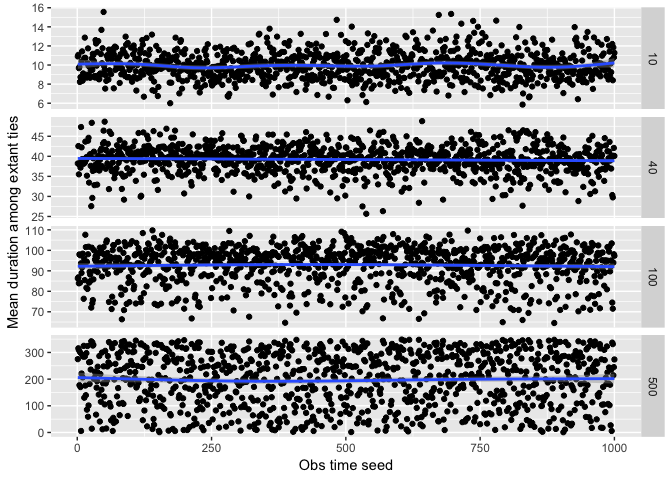

In the graphs, each dot is a simulation with a different obs time for the same expected mean within panels. All panels have a window size of 1000. The blue line is a smoother averaging across the 1000 simulations per panel. The smoother hits the expected mean for 10 and 40, but it plateaus low for 100 and it is way off for 500.

## 4.2 At what obs time do we break down for expected_dur=100

### 4.2.1 Obs time = window size = 1000

```r
sim_and_sample_durs(expected_dur=100,
           select_obs_time=1000,
           verbose=FALSE)$summary
```

```
##         all_rels extant_rels perc_error
## Min.        0.00         1.0        Inf
## 1st Qu.    29.00        29.0        0.0
## Median     68.00        70.0        2.9
## Mean       99.12       106.1        7.0
## 3rd Qu.   135.00       139.8        3.6
## Max.      970.00       797.0      -17.8
```

### 4.2.2 Obs time = 700

```r
sim_and_sample_durs(expected_dur=100,
            select_obs_time=700,
            verbose=FALSE)$summary
```

```
##         all_rels extant_rels perc_error
## Min.         0.0         1.0        Inf
## 1st Qu.     29.0        35.0       20.7
## Median      73.0        75.5        3.4
## Mean       103.5       108.2        4.5
## 3rd Qu.    144.2       148.0        2.6
## Max.       908.0       621.0      -31.6
```

### 4.2.3 Obs time = 500

```r
sim_and_sample_durs(expected_dur=100,
            select_obs_time=500,
            verbose=FALSE)$summary
```

```
##         all_rels extant_rels perc_error
## Min.        0.00         1.0        Inf
## 1st Qu.    28.00        31.0       10.7
## Median     67.00        71.0        6.0
## Mean       97.71       104.8        7.3
## 3rd Qu.   132.00       146.0       10.6
## Max.      943.00       495.0      -47.5
```

### 4.2.4 Obs time = 200

```r
sim_and_sample_durs(expected_dur=100,
            select_obs_time=200,
            verbose=FALSE)$summary
```

```
##         all_rels extant_rels perc_error
## Min.        0.00        1.00        Inf
## 1st Qu.    29.00       24.00      -17.2
## Median     68.00       54.50      -19.9
## Mean       99.01       67.53      -31.8
## 3rd Qu.   138.00      101.00      -26.8
## Max.     1105.00      195.00      -82.4
```

## 4.3 What happens when expected_dur = 500 (50% of window_size)?

Even the max obs time cannot get the mean right when it’s half of the window size.

### 4.3.1 Obs time = window size = 1000

```r
sim_and_sample_durs(expected_dur=500,
           select_obs_time=1000,
           verbose=FALSE)$summary
```

```
##         all_rels extant_rels perc_error
## Min.         0.0         1.0        Inf
## 1st Qu.    148.0       125.0      -15.5
## Median     355.0       288.0      -18.9
## Mean       501.0       342.5      -31.6
## 3rd Qu.    688.2       513.0      -25.5
## Max.      4013.0      1000.0      -75.1
```

# 5 Implications for SHAMP

Our “window” is ages 18-45, which is 27 years. Mean duration for cohabs is roughly 12 years. The equivalent of “obs_time” is the ego age.

What would we see if we sampled extant cohab ties in our sim according to the distribution of cohab ego age in the NSFG data?

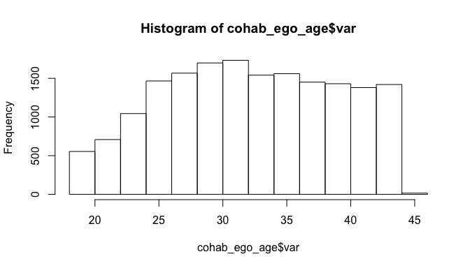

```r
data(nsfg.obj_c)
cohab_ego_age <- lookup.ego(nsfg.obj_c, 'age')
hist(cohab_ego_age$var)
```

Or, the weighted cohab ego age distribution?

Wouldn’t this more faithfully represent how the data were collected? This probably wouldn’t make a huge difference to how well we match the mean, but it seems more correct.